# bd-exercises

Alejandro Jiménez Rico

5 April 2018

# ISLR EXERCISES

### EXERCISE 3

**a)**

IV is correct. Since $s$ is increasing, the model allows more variables to fit the regression, thus letting the training RSS to decrease.

**b)**

II is correct. Adding more variables to the regression can reduce the test RSS, since the fit is being improved with more information. When too many variables are included in the regression, the model starts overfitting due to an excess of information, being trained with too much noise and thus increasing the test RSS.

**c)**

III is correct. Less constraints allows to more variables, thus increasing the variance.

**d)**

IV is correct. High bias is what causes an algorithm to *miss* some relevant information, thus underfitting. Logically, as we inccrease the number of variables we should reduce the squared bias.

**e)**

V is correct. Irreductible error does not depend on the complexity (or number of variables) of the model.

### EXERCISE 5

**a)** In a Ridge Regression, we would need to minimize

$(y_1 - \hat(\beta)_1 x_{11} - \hat{\beta}_2 x_{12})^2 + (y_2 - \hat{\beta}_1 x_{21} - \hat{\beta}_2 x_{22})^2 + \lambda (\hat{\beta}_1^2 + \hat{\beta}_2^2)$

**b)**

If we expand the previous equation, we may find
$$(y_1 - \hat\beta_1 x_{11} - \hat\beta_2 x_{12})^2 + (y_2 - \hat\beta_1 x_{21} - \hat\beta_2 x_{22})^2 + \lambda (\hat\beta_1^2 + \hat\beta_2^2) = (y_1^2 + \hat\beta_1^2 x_{11}^2 + \hat\beta_2^2 x_{12}^2 - 2 \hat\beta_1 x_{11} y_1 - 2 \hat\beta_2 x_{12} y_1 + 2 \hat\beta_1 \hat\beta_2 x_{11} x_{12}).$$

And thus,

$$y_2^2 + \hat\beta_1^2 x_{21}^2 + \hat\beta_2^2 x_{22}^2 - 2 \hat\beta_1 x_{21} y_2 - 2 \hat\beta_2 x_{22} y_2 + 2 \hat\beta_1 \hat\beta_2 x_{21} x_{22})
\lambda \hat\beta_1^2 + \lambda \hat\beta_2^2.$$

Next, we take the partial dervative to $\hat\beta_1$ and set the equation to 0, in order to minimze

$$\frac{\partial }{\partial \hat\beta_1}: (2\hat\beta_1x_{11}^2-2x_{11}y_1+2\hat\beta_2x_{11}x_{12}) + (2\hat\beta_1x_{21}^2-2x_{21}y_2+2\hat\beta_2x_{21}x_{22}) + 2\lambda\hat\beta_1 = 0.$$

Now, if we set $x_{11}=x_{12}=x_1$ and $x_{21}=x_{22}=x_2$, and we divide both sides of the equation by $2$, we my find

$$(\hat\beta_1x_1^2-x_1y_1+\hat\beta_2x_1^2) + (\hat\beta_1x_2^2-x_2y_2+\hat\beta_2x_2^2) + \lambda\hat\beta_1 = 0;$$

which is

$$\hat\beta_1 (x_1^2+x_2^2) + \hat\beta_2 (x_1^2+x_2^2) + \lambda\hat\beta_1 = x_1y_1 + x_2y_2.$$

At this moment, we may add $2\hat\beta_1x_1x_2$ and $2\hat\beta_2x_1x_2$ to both sides of the equation, and consequently find that

$$\hat\beta_1 (x_1^2 + x_2^2 + 2x_1x_2) + \hat\beta_2 (x_1^2 + x_2^2 + 2x_1x_2) + \lambda\hat\beta_1 = x_1y_1 + x_2y_2 + 2\hat\beta_1x_1x_2 + 2\hat\beta_2x_1x_2 \hat\beta_1 (x_1 + x_2)^2 + \hat\beta_2 (x_1 + x_2)^2 + \lambda\hat\beta_1$$

$$= x_1y_1 + x_2y_2 + 2\hat\beta_1x_1x_2 + 2\hat\beta_2x_1x_2.$$

And because $x_1 + x_2 = 0$, we can remove the forst two terms and find that

$$\lambda\hat\beta_1 = x_1y_1 + x_2y_2 + 2\hat\beta_1x_1x_2 + 2\hat\beta_2x_1x_2.$$

Analogously, by taking the partial derivative to $2\hat\beta_2$, we obtain

$$\lambda\hat\beta_2 = x_1y_1 + x_2y_2 + 2\hat\beta_1x_1x_2 + 2\hat\beta_2x_1x_2.$$

At this point, we should notice that the left side of the equations for both $\lambda\hat\beta_1$ and $\lambda\hat\beta_2$ are the same. Hence we have

$$\lambda\hat\beta_1 = \lambda\hat\beta_2,$$
and thus

$$\hat\beta_1 = \hat\beta_2.$$
**c)**

For a *Lasso* regression, we want to minimize $(y_1 - \hat\beta_1x_{11} - \hat\beta_2x_{12})^2 + (y_2 - \hat\beta_1x_{21} - \hat\beta_2x_{22})^2 + \lambda (|\hat\beta_1| + |\hat\beta_2|).$

**d)**

Substituting the constraint term from part *b)*, the derivative term to $\beta$ is:

$$\frac{\partial }{\partial \hat\beta} (\lambda |\beta|): \lambda\frac{|\beta|}{\beta}$$

Following through the steps in part *b)*, we obtain

$$\lambda\frac{|\beta_1|}{\beta_1} = \lambda\frac{|\beta_2|}{\beta_2}.$$

Therefore, we can infere the Lasso just requires that $\beta_1$ and $\beta_2$ are both positive or both negative.

### EXERCISE 8

**a)**

```r
set.seed(666)
x <- rnorm(100)
epsilon <- rnorm(100)
```

**b)**

```r
beta0 <- 42
set.seed(666)
beta <- trunc(runif(7)*10)

y <- beta0 + beta[[1]]*x - beta[[2]]*x^2 + beta[[3]]*x^3 + epsilon
```

**c)**

```r
library(tidyverse)
library(leaps)
library(reshape2)
regfit.full <- regsubsets(y~poly(x,10,raw=T),
                                                    data=data.frame(y,x), nvmax=10)

(reg.summary <- summary(regfit.full))
```

```
## Subset selection object
## Call: regsubsets.formula(y ~ poly(x, 10, raw = T), data = data.frame(y,
##     x), nvmax = 10)
## 10 Variables  (and intercept)
##                        Forced in Forced out
## poly(x, 10, raw = T)1      FALSE      FALSE
## poly(x, 10, raw = T)2      FALSE      FALSE
## poly(x, 10, raw = T)3      FALSE      FALSE
## poly(x, 10, raw = T)4      FALSE      FALSE
## poly(x, 10, raw = T)5      FALSE      FALSE
## poly(x, 10, raw = T)6      FALSE      FALSE
## poly(x, 10, raw = T)7      FALSE      FALSE
## poly(x, 10, raw = T)8      FALSE      FALSE
## poly(x, 10, raw = T)9      FALSE      FALSE
## poly(x, 10, raw = T)10     FALSE      FALSE
```

[output cut: 57 more lines]

```r
min.cp <- which.min(reg.summary$cp)
min.bic <- which.min(reg.summary$bic)
min.adjr2 <- which.max(reg.summary$adjr2)

df <- as_tibble(data.frame(cp = reg.summary$cp, bic = reg.summary$bic, adjr2 = reg.summary$adjr2))
df$row <- as.factor(rownames(df))
df <- df %>% melt()
df2 <- df %>%
    group_by(variable) %>%
    summarise(min = min(value),
                        max = max(value))

df3 <- left_join(df, df2) %>%
    mutate(color1 = (value == min & variable %in% c("cp","bic"))) %>%
    mutate(color2 = (value == max & variable %in% c("adjr2"))) %>%
    filter(color1 == TRUE | color2 == TRUE)
```

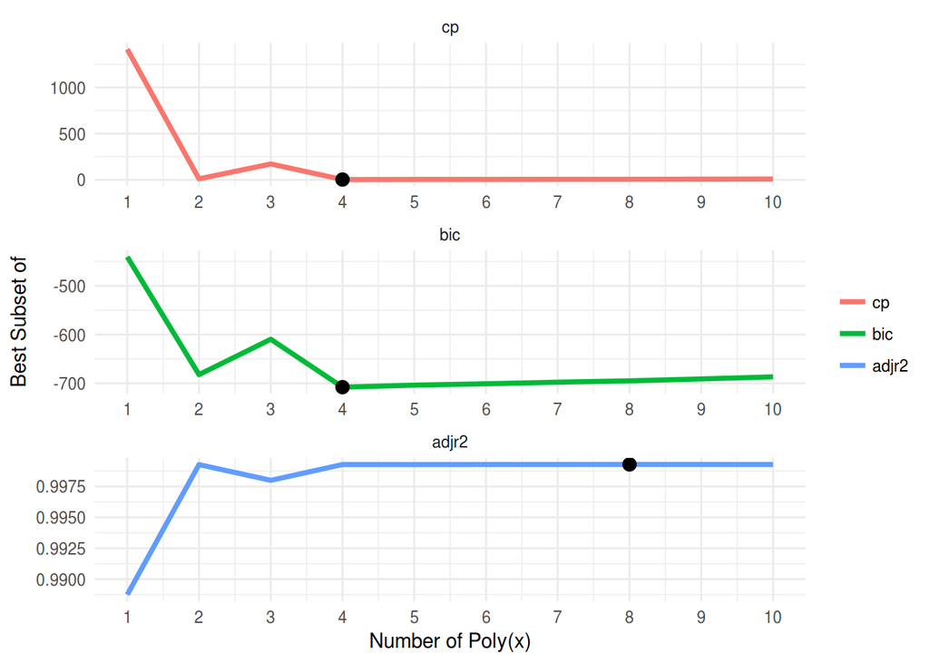

```r
df %>%
    ggplot() +
    geom_line(aes(y = value, x = as.integer(row), colour = variable), size =1.3) +
    geom_point(data = df3, aes(x = as.integer(row), y = value), color = "black", size = 3) +
    xlab("Number of Poly(x)") +
    ylab("Best Subset of") +
    facet_wrap(~variable, nrow=3, scales = "free") +
    labs(colour = "") +
    theme_minimal() +
    scale_x_continuous(breaks = c(1,2,3,4,5,6,7,8,9,10))
```

```r
coef(regfit.full, min.cp)
```

```
##           (Intercept) poly(x, 10, raw = T)1 poly(x, 10, raw = T)2
##             42.001023              6.891436             -1.079860
## poly(x, 10, raw = T)3
##              9.102142
```

```r
coef(regfit.full, min.bic)
```

```
##           (Intercept) poly(x, 10, raw = T)1 poly(x, 10, raw = T)2
##             42.001023              6.891436             -1.079860
## poly(x, 10, raw = T)3
##              9.102142
```

```r
coef(regfit.full, min.adjr2)
```

```
##           (Intercept) poly(x, 10, raw = T)1 poly(x, 10, raw = T)3
##           41.87882757            6.87731212            8.91564816
## poly(x, 10, raw = T)4 poly(x, 10, raw = T)6 poly(x, 10, raw = T)7
##           -1.47255709            0.60285495            0.08095708
## poly(x, 10, raw = T)8 poly(x, 10, raw = T)9
##           -0.07385543           -0.01662604
```

```r
rm(df)
```

**d)**

```r
# forward selection
regfit.fwd <- regsubsets(y~poly(x,10,raw=T), data=data.frame(y,x), nvmax=10)
(fwd.summary <- summary(regfit.fwd))
```

```
## Subset selection object
## Call: regsubsets.formula(y ~ poly(x, 10, raw = T), data = data.frame(y,
##     x), nvmax = 10)
## 10 Variables  (and intercept)
##                        Forced in Forced out
## poly(x, 10, raw = T)1      FALSE      FALSE
## poly(x, 10, raw = T)2      FALSE      FALSE
## poly(x, 10, raw = T)3      FALSE      FALSE
## poly(x, 10, raw = T)4      FALSE      FALSE
## poly(x, 10, raw = T)5      FALSE      FALSE
## poly(x, 10, raw = T)6      FALSE      FALSE
## poly(x, 10, raw = T)7      FALSE      FALSE
## poly(x, 10, raw = T)8      FALSE      FALSE
## poly(x, 10, raw = T)9      FALSE      FALSE
## poly(x, 10, raw = T)10     FALSE      FALSE
```

[output cut: 57 more lines]

```r
# backward selection
regfit.bwd <- regsubsets(y~poly(x,10,raw=T), data=data.frame(y,x), nvmax=10)
(bwd.summary <- summary(regfit.bwd))
```

```
## Subset selection object
## Call: regsubsets.formula(y ~ poly(x, 10, raw = T), data = data.frame(y,
##     x), nvmax = 10)
## 10 Variables  (and intercept)
##                        Forced in Forced out
## poly(x, 10, raw = T)1      FALSE      FALSE
## poly(x, 10, raw = T)2      FALSE      FALSE
## poly(x, 10, raw = T)3      FALSE      FALSE
## poly(x, 10, raw = T)4      FALSE      FALSE
## poly(x, 10, raw = T)5      FALSE      FALSE
## poly(x, 10, raw = T)6      FALSE      FALSE
## poly(x, 10, raw = T)7      FALSE      FALSE
## poly(x, 10, raw = T)8      FALSE      FALSE
## poly(x, 10, raw = T)9      FALSE      FALSE
## poly(x, 10, raw = T)10     FALSE      FALSE
```

[output cut: 57 more lines]

```r
par(mfrow=c(3,2))

min.cp <- which.min(fwd.summary$cp)
min.cp <- which.min(bwd.summary$cp)
min.bic <- which.min(fwd.summary$bic)
min.bic <- which.min(bwd.summary$bic)
min.adjr2 <- which.max(fwd.summary$adjr2)
min.adjr2 <- which.max(bwd.summary$adjr2)

# Forward
fwd.df <- data.frame(cp = fwd.summary$cp, bic = fwd.summary$bic, adjr2 = fwd.summary$adjr2)
fwd.df$row <- as.factor(rownames(fwd.df))
fwd.df <- fwd.df %>% melt()
fwd.df2 <- fwd.df %>%
    group_by(variable) %>%
    summarise(min = min(value),
                        max = max(value))

fwd.df3 <- left_join(fwd.df, fwd.df2) %>%
    mutate(color1 = (value == min & variable %in% c("cp","bic"))) %>%
    mutate(color2 = (value == max & variable %in% c("adjr2"))) %>%
    filter(color1 == TRUE | color2 == TRUE)
```

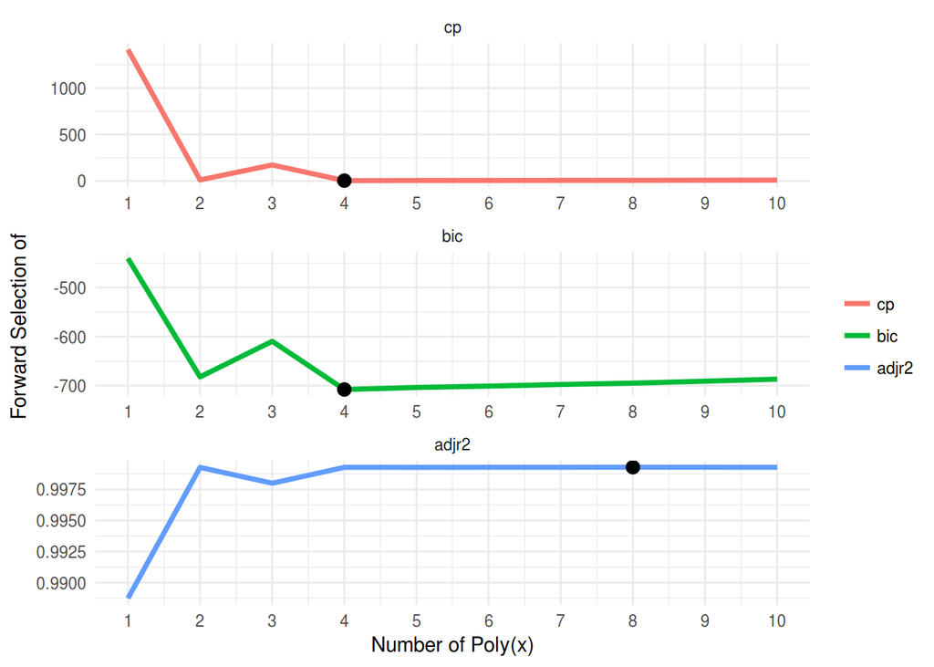

```r
fwd.df %>%
    ggplot() +
    geom_line(aes(y = value, x = as.integer(row), colour = variable), size =1.3) +
    geom_point(data = fwd.df3, aes(x = as.integer(row), y = value), color = "black", size = 3) +
    xlab("Number of Poly(x)") +
    ylab("Forward Selection of ") +
    facet_wrap(~variable, nrow=3, scales = "free") +
    labs(colour = "") +
    theme_minimal() +
    scale_x_continuous(breaks = c(1,2,3,4,5,6,7,8,9,10))
```

```r
# Backward
bwd.df <- data.frame(cp = bwd.summary$cp, bic = bwd.summary$bic, adjr2 = bwd.summary$adjr2)
bwd.df$row <- as.factor(rownames(bwd.df))
bwd.df <- bwd.df %>% melt()
bwd.df2 <- bwd.df %>%
    group_by(variable) %>%
    summarise(min = min(value),
                        max = max(value))

bwd.df3 <- left_join(bwd.df, bwd.df2) %>%
    mutate(color1 = (value == min & variable %in% c("cp","bic"))) %>%
    mutate(color2 = (value == max & variable %in% c("adjr2"))) %>%
    filter(color1 == TRUE | color2 == TRUE)
```

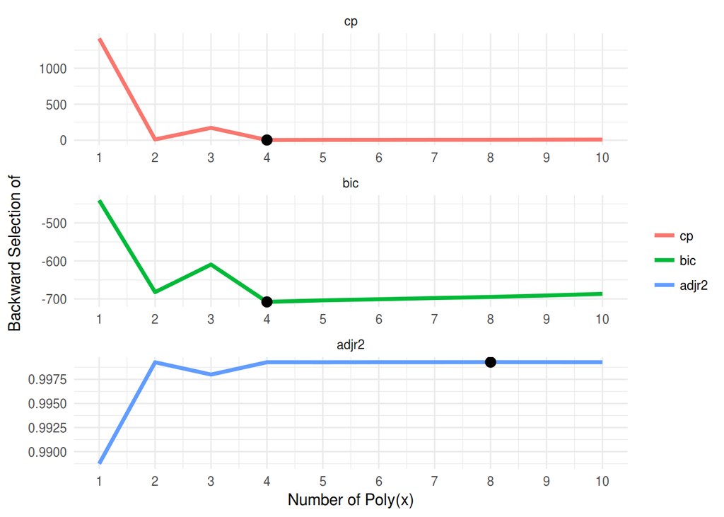

```r
bwd.df %>%
    ggplot() +
    geom_line(aes(y = value, x = as.integer(row), colour = variable), size =1.3) +
    geom_point(data = bwd.df3, aes(x = as.integer(row), y = value), color = "black", size = 3) +
    xlab("Number of Poly(x)") +
    ylab("Backward Selection of ") +
    facet_wrap(~variable, nrow=3, scales = "free") +
    labs(colour = "") +
    theme_minimal() +
    scale_x_continuous(breaks = c(1,2,3,4,5,6,7,8,9,10))
```

```r
# coefficients of selected models
coef(regfit.fwd, which.min(fwd.summary$cp))
```

```
##           (Intercept) poly(x, 10, raw = T)1 poly(x, 10, raw = T)2
##             42.001023              6.891436             -1.079860
## poly(x, 10, raw = T)3
##              9.102142
```

```r
coef(regfit.bwd, which.min(bwd.summary$cp))
```

```
##           (Intercept) poly(x, 10, raw = T)1 poly(x, 10, raw = T)2
##             42.001023              6.891436             -1.079860
## poly(x, 10, raw = T)3
##              9.102142
```

```r
coef(regfit.fwd, which.min(fwd.summary$bic))
```

```
##           (Intercept) poly(x, 10, raw = T)1 poly(x, 10, raw = T)2
##             42.001023              6.891436             -1.079860
## poly(x, 10, raw = T)3
##              9.102142
```

```r
coef(regfit.bwd, which.min(bwd.summary$bic))
```

```
##           (Intercept) poly(x, 10, raw = T)1 poly(x, 10, raw = T)2
##             42.001023              6.891436             -1.079860
## poly(x, 10, raw = T)3
##              9.102142
```

```r
coef(regfit.fwd, which.max(fwd.summary$adjr2))
```

```
##           (Intercept) poly(x, 10, raw = T)1 poly(x, 10, raw = T)3
##           41.87882757            6.87731212            8.91564816
## poly(x, 10, raw = T)4 poly(x, 10, raw = T)6 poly(x, 10, raw = T)7
##           -1.47255709            0.60285495            0.08095708
## poly(x, 10, raw = T)8 poly(x, 10, raw = T)9
##           -0.07385543           -0.01662604
```

```r
coef(regfit.bwd, which.max(bwd.summary$adjr2))
```

```
##           (Intercept) poly(x, 10, raw = T)1 poly(x, 10, raw = T)3
##           41.87882757            6.87731212            8.91564816
## poly(x, 10, raw = T)4 poly(x, 10, raw = T)6 poly(x, 10, raw = T)7
##           -1.47255709            0.60285495            0.08095708
## poly(x, 10, raw = T)8 poly(x, 10, raw = T)9
##           -0.07385543           -0.01662604
```

**e)**

```r
library(glmnet)
xmat <- model.matrix(y~poly(x,10,raw=T))[,-1]
lasso.mod <- cv.glmnet(xmat, y, alpha=1)
(lambda <- lasso.mod$lambda.min)
```

```
## [1] 0.6124931
```

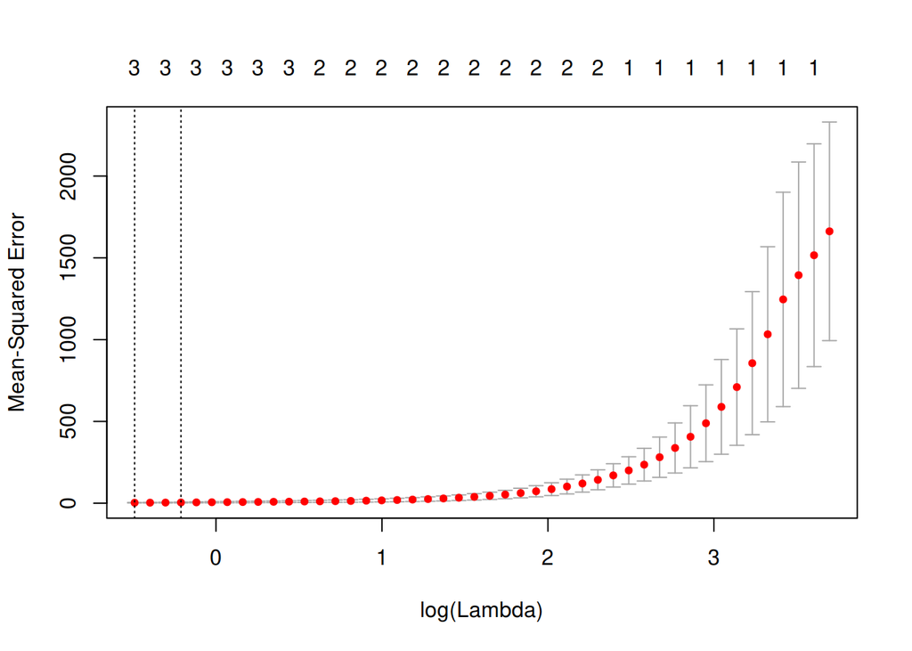

```r
par(mfrow=c(1,1))
plot(lasso.mod)
```

```r
predict(lasso.mod, s=lambda, type="coefficients")
```

```
## 11 x 1 sparse Matrix of class "dgCMatrix"
##                                 1
## (Intercept)            41.5362806
## poly(x, 10, raw = T)1   6.3394676
## poly(x, 10, raw = T)2  -0.6744091
## poly(x, 10, raw = T)3   9.0972175
## poly(x, 10, raw = T)4   .
## poly(x, 10, raw = T)5   .
## poly(x, 10, raw = T)6   .
## poly(x, 10, raw = T)7   .
## poly(x, 10, raw = T)8   .
## poly(x, 10, raw = T)9   .
## poly(x, 10, raw = T)10  .
```

Now if we remember our $\beta_0$ and $\beta_i$, we may conclude that the best results come from the *cp* model and *bic*.

```r
print(beta0)
```

```
## [1] 42
```

```r
print(beta)
```

```
## [1] 7 1 9 2 3 7 9
```

**f)**

```r
y2 <- beta0 + beta[[7]]*x^7 + epsilon

# best subset model selection
regfit.full <- regsubsets(y2~poly(x,10,raw=T), data=data.frame(y,x), nvmax=10)
(reg.summary <- summary(regfit.full))
```

```
## Subset selection object
## Call: regsubsets.formula(y2 ~ poly(x, 10, raw = T), data = data.frame(y,
##     x), nvmax = 10)
## 10 Variables  (and intercept)
##                        Forced in Forced out
## poly(x, 10, raw = T)1      FALSE      FALSE
## poly(x, 10, raw = T)2      FALSE      FALSE
## poly(x, 10, raw = T)3      FALSE      FALSE
## poly(x, 10, raw = T)4      FALSE      FALSE
## poly(x, 10, raw = T)5      FALSE      FALSE
## poly(x, 10, raw = T)6      FALSE      FALSE
## poly(x, 10, raw = T)7      FALSE      FALSE
## poly(x, 10, raw = T)8      FALSE      FALSE
## poly(x, 10, raw = T)9      FALSE      FALSE
## poly(x, 10, raw = T)10     FALSE      FALSE
```

[output cut: 57 more lines]

```r
min.cp <- which.min(reg.summary$cp)
min.bic <- which.min(reg.summary$bic)
min.adjr2 <- which.max(reg.summary$adjr2)
coef(regfit.full, min.cp)
```

```
##            (Intercept)  poly(x, 10, raw = T)5  poly(x, 10, raw = T)7
##          41.9740684519           0.1035155540           8.9798052582
## poly(x, 10, raw = T)10
##          -0.0003794842
```

```r
coef(regfit.full, min.bic)
```

```
##           (Intercept) poly(x, 10, raw = T)7
##             41.930878              9.001516
```

```r
coef(regfit.full, min.adjr2)
```

```
##           (Intercept) poly(x, 10, raw = T)3 poly(x, 10, raw = T)4
##           42.02231529           -0.67146177           -0.36457583
## poly(x, 10, raw = T)5 poly(x, 10, raw = T)6 poly(x, 10, raw = T)7
##            0.53830159            0.21165375            8.91471627
## poly(x, 10, raw = T)8
##           -0.03097828
```

```r
# Reg
reg.df <- data.frame(cp = reg.summary$cp, bic = reg.summary$bic, adjr2 = reg.summary$adjr2)
reg.df$row <- as.factor(rownames(reg.df))
reg.df <- reg.df %>% melt()
reg.df2 <- reg.df %>%
    group_by(variable) %>%
    summarise(min = min(value),
                        max = max(value))

reg.df3 <- left_join(reg.df, reg.df2) %>%
    mutate(color1 = (value == min & variable %in% c("cp","bic"))) %>%
    mutate(color2 = (value == max & variable %in% c("adjr2"))) %>%
    filter(color1 == TRUE | color2 == TRUE)
```

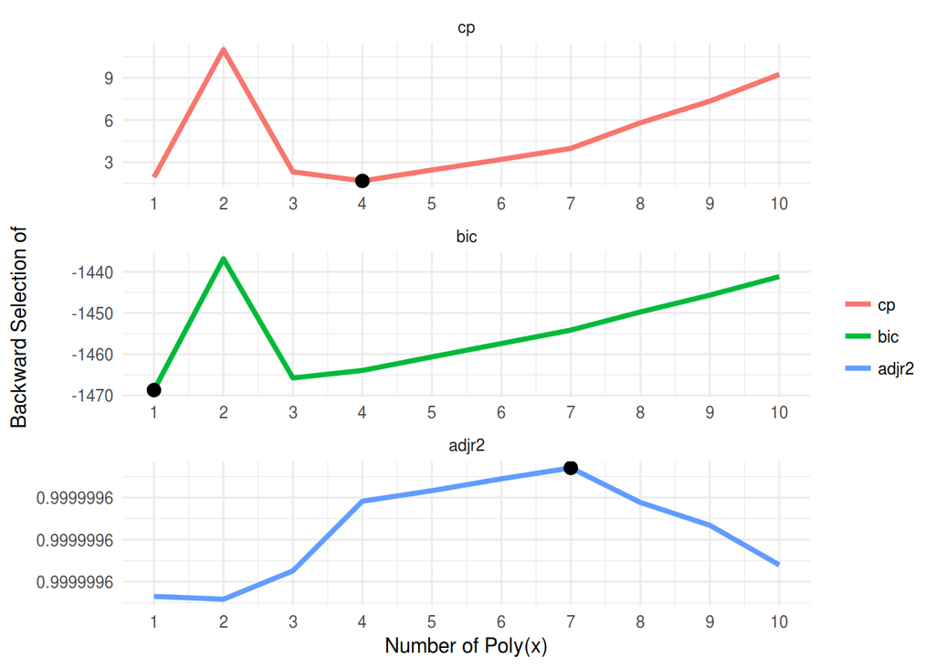

```r
reg.df %>%
    ggplot() +
    geom_line(aes(y = value, x = as.integer(row), colour = variable), size =1.3) +
    geom_point(data = reg.df3, aes(x = as.integer(row), y = value), color = "black", size = 3) +
    xlab("Number of Poly(x)") +
    ylab("Backward Selection of ") +
    facet_wrap(~variable, nrow=3, scales = "free") +
    labs(colour = "") +
    theme_minimal() +
    scale_x_continuous(breaks = c(1,2,3,4,5,6,7,8,9,10))
```

```r
# lasso regression
xmat <- model.matrix(y2~poly(x,10,raw=T))[,-1]
lasso.mod <- cv.glmnet(xmat, y2, alpha=1)
(lambda <- lasso.mod$lambda.min)
```

```
## [1] 56.44925
```

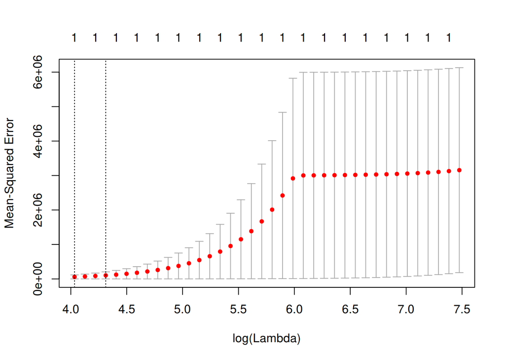

```r
par(mfrow=c(1,1))
plot(lasso.mod)
```

```r
predict(lasso.mod, s=lambda, type="coefficients")
```

```
## 11 x 1 sparse Matrix of class "dgCMatrix"
##                                1
## (Intercept)            37.436370
## poly(x, 10, raw = T)1   .
## poly(x, 10, raw = T)2   .
## poly(x, 10, raw = T)3   .
## poly(x, 10, raw = T)4   .
## poly(x, 10, raw = T)5   .
## poly(x, 10, raw = T)6   .
## poly(x, 10, raw = T)7   8.713534
## poly(x, 10, raw = T)8   .
## poly(x, 10, raw = T)9   .
## poly(x, 10, raw = T)10  .
```

### EXERCISE 9

**a)**

```r
library(ISLR)
data(College)
set.seed(1)
trainid <- sample(1:nrow(College), nrow(College)/2)
train <- College[trainid,]
test <- College[-trainid,]
str(College)
```

```
## 'data.frame':    777 obs. of  18 variables:
##  $ Private    : Factor w/ 2 levels "No","Yes": 2 2 2 2 2 2 2 2 2 2 ...
##  $ Apps       : num  1660 2186 1428 417 193 ...
##  $ Accept     : num  1232 1924 1097 349 146 ...
##  $ Enroll     : num  721 512 336 137 55 158 103 489 227 172 ...
##  $ Top10perc  : num  23 16 22 60 16 38 17 37 30 21 ...
##  $ Top25perc  : num  52 29 50 89 44 62 45 68 63 44 ...
##  $ F.Undergrad: num  2885 2683 1036 510 249 ...
##  $ P.Undergrad: num  537 1227 99 63 869 ...
##  $ Outstate   : num  7440 12280 11250 12960 7560 ...
##  $ Room.Board : num  3300 6450 3750 5450 4120 ...
##  $ Books      : num  450 750 400 450 800 500 500 450 300 660 ...
##  $ Personal   : num  2200 1500 1165 875 1500 ...
##  $ PhD        : num  70 29 53 92 76 67 90 89 79 40 ...
##  $ Terminal   : num  78 30 66 97 72 73 93 100 84 41 ...
##  $ S.F.Ratio  : num  18.1 12.2 12.9 7.7 11.9 9.4 11.5 13.7 11.3 11.5 ...
##  $ perc.alumni: num  12 16 30 37 2 11 26 37 23 15 ...
##  $ Expend     : num  7041 10527 8735 19016 10922 ...
##  $ Grad.Rate  : num  60 56 54 59 15 55 63 73 80 52 ...
```

**b)**

```r
fit.lm <- lm(Apps~., data=train)
pred.lm <- predict(fit.lm, test)
(err.lm <- mean((test$Apps - pred.lm)^2))  # test error
```

```
## [1] 1108531
```

**c)**

```r
library(glmnet)
xmat.train <- model.matrix(Apps~., data=train)[,-1]
xmat.test <- model.matrix(Apps~., data=test)[,-1]
fit.ridge <- cv.glmnet(xmat.train, train$Apps, alpha=0)
(lambda <- fit.ridge$lambda.min)  # optimal lambda
```

```
## [1] 450.7435
```

```r
pred.ridge <- predict(fit.ridge, s=lambda, newx=xmat.test)
(err.ridge <- mean((test$Apps - pred.ridge)^2))  # test error
```

```
## [1] 1037616
```

**d)**

```r
library(glmnet)
xmat.train <- model.matrix(Apps~., data=train)[,-1]
xmat.test <- model.matrix(Apps~., data=test)[,-1]
fit.lasso <- cv.glmnet(xmat.train, train$Apps, alpha=1)
(lambda <- fit.lasso$lambda.min)  # optimal lambda
```

```
## [1] 29.65591
```

```r
pred.lasso <- predict(fit.lasso, s=lambda, newx=xmat.test)
(err.lasso <- mean((test$Apps - pred.lasso)^2))  # test error
```

```
## [1] 1025248
```

```r
coef.lasso <- predict(fit.lasso, type="coefficients", s=lambda)[1:ncol(College),]
coef.lasso[coef.lasso != 0]
```

```
##   (Intercept)    PrivateYes        Accept        Enroll     Top10perc
## -4.514223e+02 -4.814352e+02  1.535012e+00 -4.035455e-01  4.668170e+01
##     Top25perc   F.Undergrad      Outstate    Room.Board           PhD
## -7.091364e+00 -3.426988e-03 -5.020064e-02  1.851610e-01 -3.849885e+00
##      Terminal   perc.alumni        Expend     Grad.Rate
## -3.443747e+00 -2.117870e+00  3.192846e-02  2.695730e+00
```

```r
length(coef.lasso[coef.lasso != 0])
```

```
## [1] 14
```

**g)**

```r
library(viridis)
```

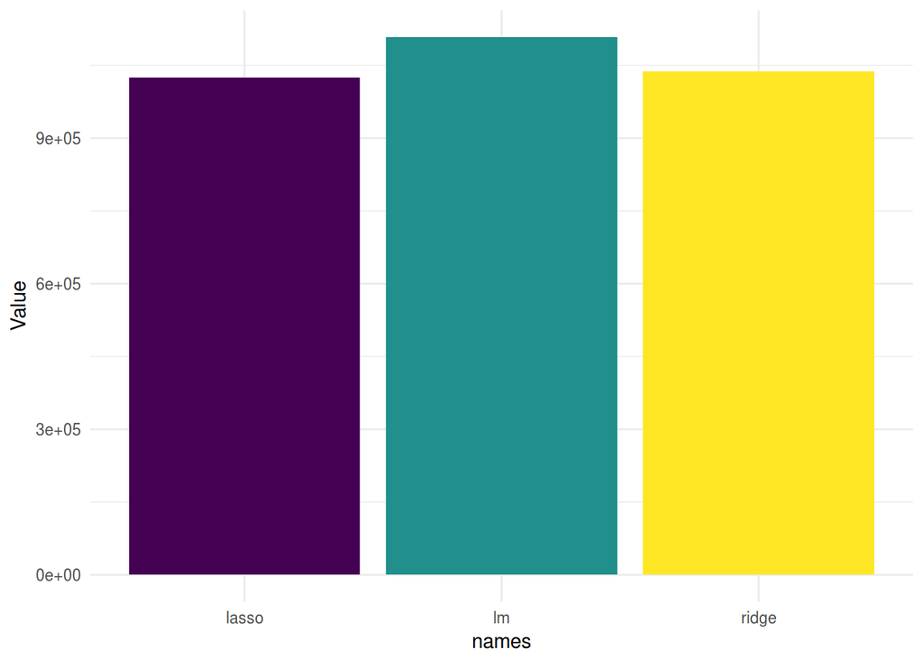

```r
err.all <- c(err.lm, err.ridge, err.lasso)
df <- as.data.frame(err.all)
df$names<- c("lm", "ridge", "lasso")
 df%>%
    ggplot() +
    geom_bar(aes(y = err.all, x = names, fill = names), stat = "identity") +
    scale_fill_viridis(discrete = TRUE) +
    theme_minimal() +
    theme(legend.position="none") +
    ylab("Value")
```

### EXERCISE 10

**a)**

```r
set.seed(666)
epsilon <- rnorm(1000)
xmat <- matrix(rnorm(1000*20), ncol=20)
beta <- round(runif(20)*10-5)
y <- xmat %*% beta + epsilon
```

**b)**

```r
set.seed(666)
trainid <- sample(1:1000, 100, replace = FALSE)
xmat.train <- xmat[trainid,]
xmat.test <- xmat[-trainid,]
y.train <- y[trainid,]
y.test <- y[-trainid,]
train <- data.frame(y=y.train, xmat.train)
test <- data.frame(y=y.test, xmat.test)
```

**c)**

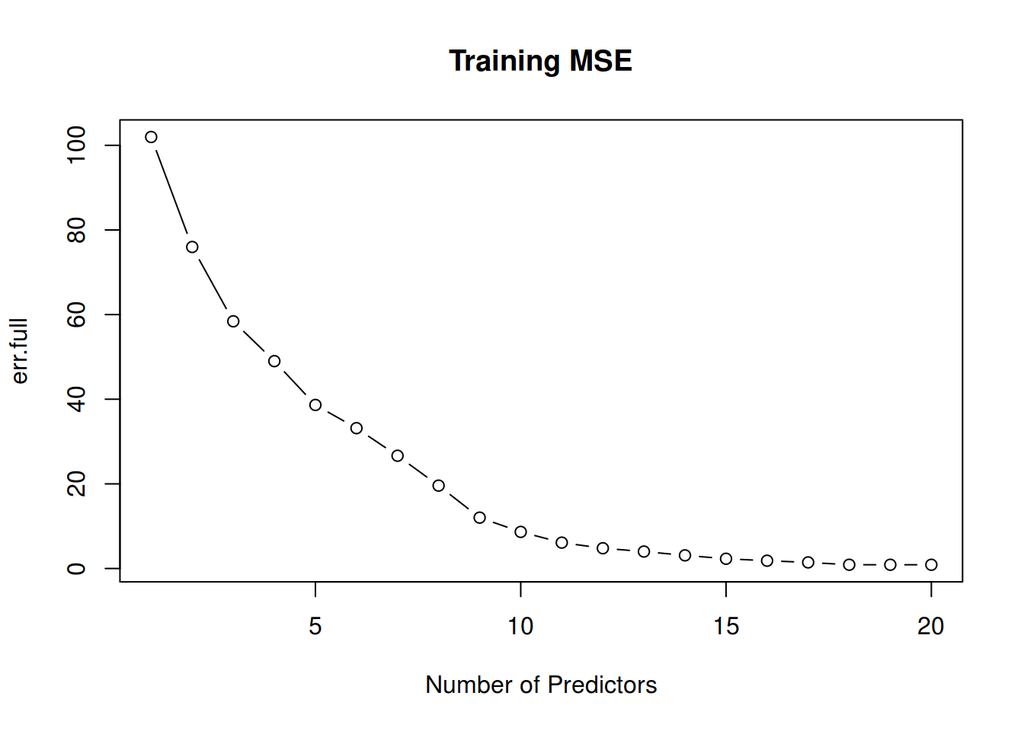

```r
library(leaps)

predict.regsubsets <- function(object, newdata, id, ...){
  form <- as.formula(object$call[[2]])
  mat <- model.matrix(form, newdata)
  coefi <- coef(object, id=id)
  xvars <- names(coefi)
  mat[,xvars]%*%coefi
}

regfit.full <- regsubsets(y~., data=train, nvmax=20)
err.full <- rep(NA, 20)
for(i in 1:20) {
  pred.full <- predict(regfit.full, train, id=i)
  err.full[i] <- mean((train$y - pred.full)^2)
}
plot(1:20, err.full, type="b", main="Training MSE", xlab="Number of Predictors")
```

```r
which.min(err.full)  # min for train error should be at max pred count
```

```
## [1] 20
```

**d)**

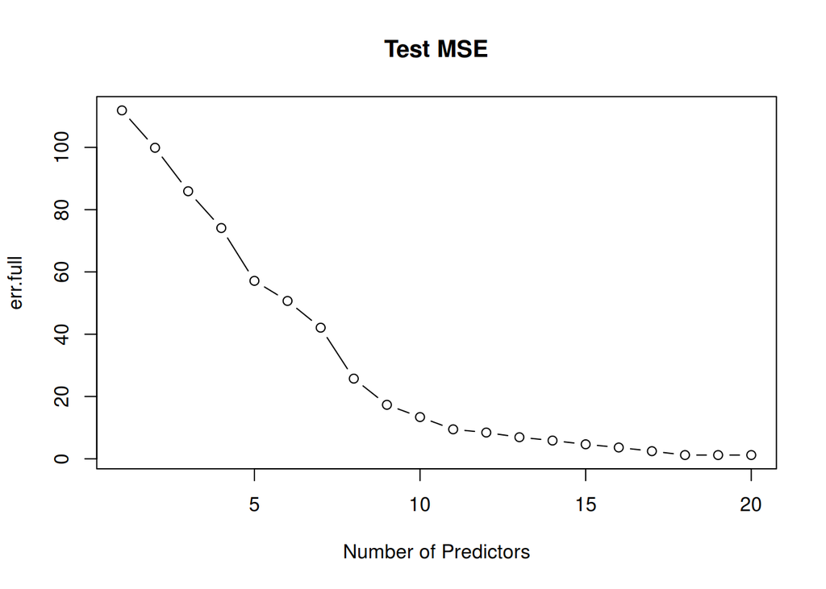

```r
err.full <- rep(NA, 20)
for(i in 1:20) {
  pred.full <- predict(regfit.full, test, id=i)
  err.full[i] <- mean((test$y - pred.full)^2)
}
plot(1:20, err.full, type="b", main="Test MSE", xlab="Number of Predictors")
```

**e)**

```r
which.min(err.full)
```

```
## [1] 19
```

**f)**

```r
(coef.best <- coef(regfit.full, id=which.min(err.full)))
```

```
## (Intercept)          X1          X2          X3          X4          X5
## -0.15299620  1.03749819  4.05766473 -0.06082337  1.05389515  0.94861295
##          X6          X7          X8          X9         X10         X11
## -5.15941777  1.18110201 -4.05289132  2.98451574  1.01496831  4.01110029
##         X12         X13         X14         X15         X16         X17
##  3.01023984 -3.08423631 -1.99815735  2.19217597  4.03095759 -0.82581744
##         X18         X20
## -1.04333895  3.12295285
```

```r
beta[beta != 0]
```

```
##  [1]  1  4  1  1 -5  1 -4  3  1  4  3 -3 -2  2  4 -1 -1  3
```

```r
names(beta) <- paste0("X", 1:20)
merge(data.frame(beta=names(beta),beta), data.frame(beta=names(coef.best),coef.best), all.x=T, sort=F)
```

```
##    beta beta.1   coef.best
## 1    X1      1  1.03749819
## 2    X2      4  4.05766473
## 3    X3      0 -0.06082337
## 4    X4      1  1.05389515
## 5    X5      1  0.94861295
## 6    X6     -5 -5.15941777
## 7    X7      1  1.18110201
## 8    X8     -4 -4.05289132
## 9    X9      3  2.98451574
## 10  X10      1  1.01496831
## 11  X11      4  4.01110029
## 12  X12      3  3.01023984
## 13  X13     -3 -3.08423631
## 14  X14     -2 -1.99815735
## 15  X15      2  2.19217597
## 16  X16      4  4.03095759
## 17  X17     -1 -0.82581744
## 18  X18     -1 -1.04333895
## 19  X20      3  3.12295285
## 20  X19      0          NA
```

**g)**

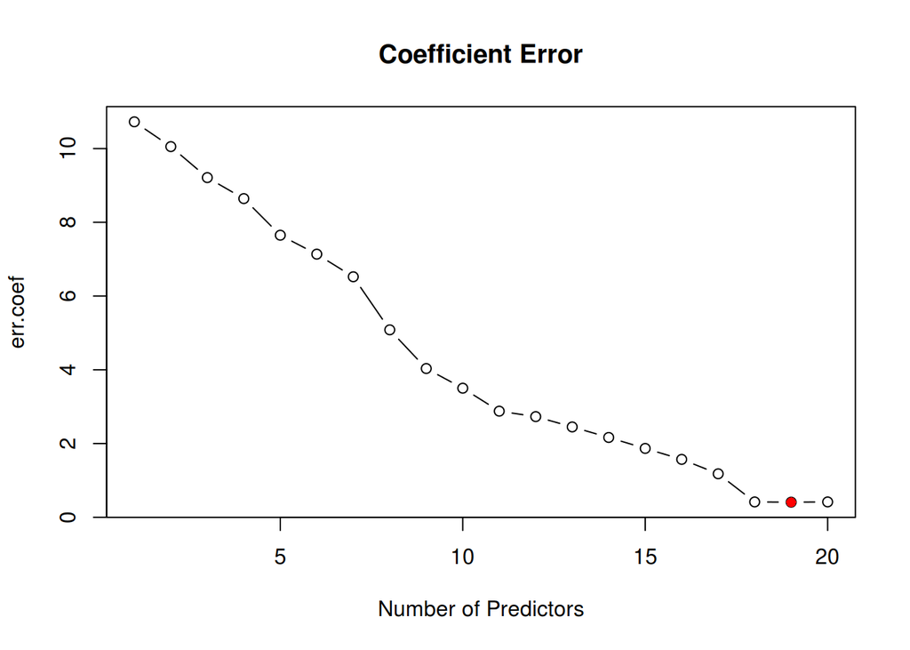

```r
err.coef <- rep(NA, 20)
for(i in 1:20) {
  coef.i <- coef(regfit.full, id=i)
  df.err <- merge(data.frame(beta=names(beta),beta), data.frame(beta=names(coef.i),coef.i), all.x=T)
  df.err[is.na(df.err[,3]),3] <- 0
  err.coef[i] <- sqrt(sum((df.err[,2] - df.err[,3])^2))
}
plot(1:20, err.coef, type="b", main="Coefficient Error", xlab="Number of Predictors")
points(which.min(err.coef), err.coef[which.min(err.coef)], col="red", pch=16)
```